# Greater Melbourne Transit Supply Index (SI) scores for SA1 2021 boundaries

James Reynolds

2024-02-14

# Introduction

Monash University’s Public Transport Research Group (PTRG) is commencing a project that will make use of hourly Transit Service Index (SI) scores for Statistical Area Level 1 (SA1) 2021 census boundaries within Greater Melbourne. Code to calculate SI scores from GTFS datasets has recently been developed into an R package. Development of that code is reported separately (see Reynolds (2024)).

Reynolds, James. 2024. “Gtfssupplyindex.” https://github.com/James-Reynolds/gtfssupplyindex.

The next step, therefore, is to output the SI scores for Greater Melbourne and check the results. This document describes the calculation of the SI scores for SA1 zones in Greater Melbourne for Tuesday July 25th, Saturday 29th and Sunday 30th, 2023. These dates were selected as they are after universities commence their second semester, clear of public holiday, but also appear to be before strike action in September and October

Earlier versions of this work calculated scores for dates in early October. On closer inspection it appears that strike action may have resulted in many typical bus services not being provided on Sundays at that time.

The rest of this document is structured as follows: the next section discusses the research context of the the Supply Index. This is followed by a brief discussion of the methodology. In the fourth section results are presented, including SI scores for SA1s across Greater Melbourne on an hour-by-hour basis. Results are then discussed, followed by a brief conclusion that includes the identification of directions for future research.

# Research context

## GTFS

The introduction of the General Transit Feed Specification (GTFS) and widespread release of schedule data in this format has helped towards making transit metrics more broadly available and useable. GTFS is an open, text-based format that was developed originally to allow transit information to be included in the Google Maps navigation platform (MobilityData undated). The data structure is shown in the below figure.

MobilityData. undated. *General Transit Feed Specification (GTFS)*. {https://gtfs.org/}.

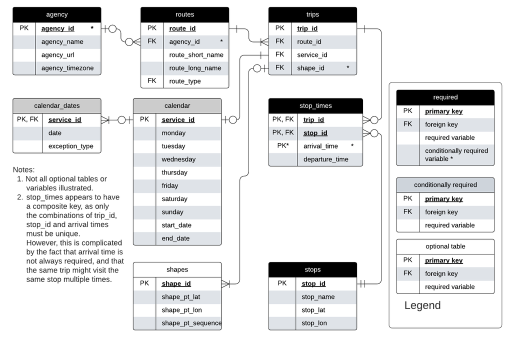

GTFS entity relationship diagram. Source: adapted by author from Alamri et al (2023) and the GTFS Schedule Reference (16/11/2023 revision).

In the Entity Relationship Diargram (ERD) shown above, each box represents a database table in the GTFS, with table rows indicating the variables (columns) included in each. Relationships between the tables are indicated by the connecting lines, and Primary Key (PK) and Foreign Key (FK) designations. “Crow’s feet” indicate the relationships between each table.

For example, each record in the ‘stops’ table includes a value for stop_id, stop_name, stop_lat and stop_lon.

For example, stop_id also appears in the ‘stop_times’ table as a Primary Key and Foreign Key.

See https://i.stack.imgur.com/fxaAq.png for guide to the symbols. But, for example, the stops table is required, with the stop_id field providing a unique (primary) key for every stop. Within the stop_times table (which is also required) the stop_id field is a foreign key. Each unique stop_id can appear many times in the stop_times table, but must appear only once in the stops table. In the stop_times table each combination of trip_id, stop_id and arrival time must be unique (But, see note 2!) meaning that these fields represent a composite key.

## The Transit Suppy Index

$$\begin{equation}
SI_{area, time} = \sum{\frac{Area_{Bn}}{Area_{area}}*SL_{n, time}}
\end{equation}$$

The Transit Supply Index (SI) was developed by Currie and Senbergs (2007). Its equation is shown in the margin

Currie, Graham, and Zed Senbergs. 2007. “Identifying spatial gaps in public transport provision for socially disadvantaged Australians: the Melbourne needs-gap study.” Australasian Transport Research Forum.

(1) $SI_{area, time}$ is the Supply Index for the area of interest and a given period of time; (2) $Area_{Bn}$ is the buffer area for each stop (n) within the area of interest. In Currie and Senbergs (2007) this was based on a radius of 400 metres for bus and tram stops, and 800 metres for railway stations; (3) $Area_{area}$ is the area of the area of interest; and (4) $SL_{n,time}$ is the number of transit arrivals for each stop for a given time period. Minor adjustments have been made to generalise the equation, as Currie and Senbergs (2007) focus was the context of Melbourne’s Census Collection Districts (CCD) and calculations based on a week of transit service. CCDs predate the introduction of Statistical Areas 1, 2, 3, and 4 (SA1, SA2, SA3, SA4), and other geographical divisions currently used by the Australian Bureau of Statistics (ABS), which may be more familiar to readers.

An advantage of the SI is that it is a relatively simple number to calculate, understand and explain. It describes the number of transit arrivals at stops within an area of interest and time frame, multiplied by a factor accounting for the proportion of the area of interest that is within typical walking distance of each stop. Hence, more services, more stops and higher frequencies would all increase the SI score.

Simplicity is also helped by the way that the Index is additive. $SI_{area, time}$ scores can be aggregated to calculate an overall score across multiple time periods or for a region encompassing multiple areas of interest.

## gtfssupplyindex R package

R (R Core Team 2023) is a widely used and readily available statistical programming language. This was adopted for development of a package of functions and tools to calculate SI scores from a GTFS dataset. The package development setup and workflow described by Wickham and Bryan (2023) was adopted. The package is available and documented on github (Reynolds 2024).

R Core Team. 2023. *R: A Language and Environment for Statistical Computing*. Vienna, Austria: R Foundation for Statistical Computing. https://www.R-project.org/.

Wickham, Hadley, and Jennifer Bryan. 2023. *R Packages*. " O’Reilly Media, Inc.". https://r-pkgs.org/.

Reynolds, James. 2024. “Gtfssupplyindex.” https://github.com/James-Reynolds/gtfssupplyindex.

The structure and functions used to generate each table are shown in the below Entity Relationship Diagram (ERD).

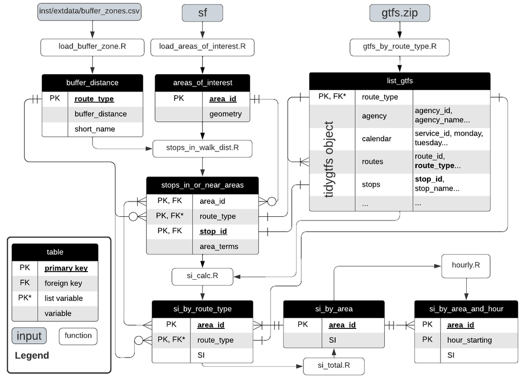

Entity Relationship Diagram (ERD) showing the data structure and functions of the gtfssupplyindex package

The package takes input from three files:

- a gtfs feed (gtfs.zip)
- a sf object describing the geometry of the areas for which the SI is to be calculated
- a csv file defining the buffer zone distances (in metres) for each route_type - a version of this file is included in the package.

The ultimate goal of the functions included in the gtfssupplyindex package is to output either a si_by_area table (bottom row, second from right) or the si_by_area_and_hour table (bottom right). which reports the SI score for each hour of the day across dates specified by the user.

Included in the package is an example GTFS dataset from the Mornington Penninsula Tourist Railway. The output (si_by_area_and_hour) table is shown as an example below.

Mornington Penninsula Tourist Railway hourly SI values for December 30, 2018, for SA1 zones, first six entries — THIS IS WHAT THE si_by_area_and_hour TABLE LOOKS LIKE

| area_id | SI | hour_starting |
| --- | --- | --- |
| 214021381 | 0.0000672 | 10:00 |
| 214021385 | 0.0000000 | 10:00 |
| 214021591 | 0.2436873 | 10:00 |
| 214021592 | 0.0684965 | 10:00 |
| 214021381 | 0.0522962 | 11:00 |
| 214021385 | 0.0067970 | 11:00 |

Mornington Penninsula Tourist Railway hourly SI values for December 30, 2018, for SA1 zones, by hour — THIS IS A ‘WIDER’ VERSION OF THE si_by_area_and_hour TABLE

| area_id | 10:00 | 11:00 | 12:00 | 13:00 | 14:00 | 15:00 |
| --- | --- | --- | --- | --- | --- | --- |
| 214021381 | 0.0000672 | 0.0522962 | 0.0523635 | 0.0000672 | 0.0522962 | 0.0523635 |
| 214021385 | 0.0000000 | 0.0067970 | 0.0067970 | 0.0000000 | 0.0067970 | 0.0067970 |
| 214021591 | 0.2436873 | 0.1366432 | 0.3803305 | 0.1366432 | 0.2436873 | 0.3803305 |
| 214021592 | 0.0684965 | 0.0000000 | 0.0684965 | 0.0000000 | 0.0684965 | 0.0684965 |

The upper table shows first six entries in the ‘longer’ version of the table. Each record shows the SI score for a unique combination of area_id and hour_starting. The lower table shows the same data, but in a ‘wider’ format so that all hour_starting SI scores a visible. Further details of the Mornington Penninsula Railway calculations are available in the package documentation on github(Reynolds 2024).

The Mornington Penninsula Railway only runs between 10am and 4pm on the day in question.

Including hand verification.

Reynolds, James. 2024. “Gtfssupplyindex.” https://github.com/James-Reynolds/gtfssupplyindex.

# Methodology - July 2023

Here the July 14th 2023 feed was used. SI results were calculated for July 25th, 29th and 30th, 2023. These dates were selected as they are after universities commence their second semester, clear of public holiday, but also appear to be before strike action in September and October

Hourly SI scores were obtained for all modes across all of Greater Melbourne.

Victorian GTFS and SA1 zones within the Greater Melbourne GCCSA, hourly SI values for July 25, 2023, first 6 SA1 zones, 6am to 11pm only

| area_id | 6:00 | 7:00 | 8:00 | 9:00 | 10:00 | 11:00 | 12:00 | 13:00 | 14:00 | 15:00 | 16:00 | 17:00 | 18:00 | 19:00 | 20:00 | 21:00 | 22:00 |
| --- | --- | --- | --- | --- | --- | --- | --- | --- | --- | --- | --- | --- | --- | --- | --- | --- | --- |
| 20601110601 | 27 | 45 | 51 | 51 | 43 | 39 | 38 | 43 | 38 | 47 | 51 | 51 | 51 | 32 | 23 | 18 | 8 |
| 20601110605 | 86 | 99 | 93 | 85 | 73 | 69 | 65 | 67 | 75 | 88 | 103 | 100 | 86 | 65 | 44 | 38 | 29 |
| 20601110606 | 69 | 84 | 84 | 73 | 68 | 62 | 60 | 61 | 67 | 75 | 90 | 85 | 70 | 56 | 35 | 29 | 19 |
| 20601110608 | 24 | 36 | 39 | 36 | 32 | 29 | 29 | 30 | 30 | 34 | 39 | 38 | 33 | 25 | 17 | 13 | 9 |
| 20601110609 | 64 | 90 | 90 | 89 | 74 | 69 | 66 | 69 | 72 | 82 | 97 | 97 | 85 | 68 | 50 | 41 | 29 |
| 20601110610 | 99 | 137 | 131 | 133 | 108 | 102 | 95 | 99 | 106 | 121 | 146 | 150 | 130 | 107 | 82 | 66 | 50 |

Victorian GTFS and SA1 zones within the Greater Melbourne GCCSA, hourly SI values for July 29, 2023, first 6 SA1 zones, 6am to 11pm only

| area_id | 6:00 | 7:00 | 8:00 | 9:00 | 10:00 | 11:00 | 12:00 | 13:00 | 14:00 | 15:00 | 16:00 | 17:00 | 18:00 | 19:00 | 20:00 | 21:00 | 22:00 |
| --- | --- | --- | --- | --- | --- | --- | --- | --- | --- | --- | --- | --- | --- | --- | --- | --- | --- |
| 20601110601 | 17 | 22 | 28 | 29 | 28 | 28 | 30 | 30 | 30 | 30 | 30 | 26 | 28 | 20 | 14 | 12 | 11 |
| 20601110605 | 42 | 45 | 52 | 62 | 57 | 64 | 65 | 68 | 58 | 58 | 58 | 58 | 54 | 39 | 34 | 28 | 27 |
| 20601110606 | 30 | 37 | 44 | 52 | 46 | 55 | 55 | 59 | 49 | 49 | 48 | 47 | 42 | 28 | 24 | 19 | 18 |
| 20601110608 | 12 | 16 | 20 | 22 | 20 | 22 | 24 | 25 | 23 | 23 | 21 | 21 | 19 | 16 | 11 | 10 | 9 |
| 20601110609 | 39 | 44 | 50 | 56 | 53 | 58 | 58 | 59 | 57 | 57 | 56 | 56 | 54 | 48 | 37 | 32 | 30 |
| 20601110610 | 64 | 71 | 77 | 87 | 83 | 90 | 88 | 88 | 88 | 88 | 87 | 89 | 85 | 80 | 65 | 54 | 51 |

Victorian GTFS and SA1 zones within the Greater Melbourne GCCSA, hourly SI values for July 30, 2023, first 6 SA1 zones, 6am to 11pm only

| area_id | 6:00 | 7:00 | 8:00 | 9:00 | 10:00 | 11:00 | 12:00 | 13:00 | 14:00 | 15:00 | 16:00 | 17:00 | 18:00 | 19:00 | 20:00 | 21:00 | 22:00 |
| --- | --- | --- | --- | --- | --- | --- | --- | --- | --- | --- | --- | --- | --- | --- | --- | --- | --- |
| 20601110601 | 3 | 3 | 10 | 16 | 13 | 21 | 16 | 22 | 16 | 22 | 16 | 22 | 12 | 18 | 9 | 9 | 6 |
| 20601110605 | 0 | 11 | 27 | 29 | 38 | 44 | 43 | 43 | 44 | 44 | 44 | 45 | 45 | 35 | 31 | 27 | 28 |
| 20601110606 | 5 | 10 | 16 | 21 | 27 | 33 | 33 | 33 | 33 | 33 | 32 | 31 | 28 | 21 | 18 | 16 | 17 |
| 20601110608 | 5 | 5 | 7 | 10 | 14 | 17 | 17 | 18 | 17 | 18 | 16 | 17 | 10 | 10 | 7 | 7 | 6 |
| 20601110609 | 3 | 12 | 29 | 36 | 42 | 51 | 49 | 53 | 48 | 53 | 47 | 52 | 44 | 43 | 32 | 27 | 26 |
| 20601110610 | 0 | 18 | 51 | 63 | 70 | 84 | 82 | 87 | 80 | 87 | 79 | 87 | 81 | 77 | 59 | 48 | 47 |

SI scores were also obtained for each mode separately.

## Tram

Victorian GTFS and SA1 zones within the Greater Melbourne GCCSA, hourly SI values for July 25, 2023, tram only, first 6 SA1 zones, 6am to 11pm only

| area_id | 6:00 | 7:00 | 8:00 | 9:00 | 10:00 | 11:00 | 12:00 | 13:00 | 14:00 | 15:00 | 16:00 | 17:00 | 18:00 | 19:00 | 20:00 | 21:00 | 22:00 |
| --- | --- | --- | --- | --- | --- | --- | --- | --- | --- | --- | --- | --- | --- | --- | --- | --- | --- |
| 20601110601 | 10 | 13 | 16 | 16 | 14 | 13 | 12 | 13 | 12 | 14 | 15 | 15 | 16 | 14 | 8 | 6 | 5 |
| 20601110605 | 54 | 68 | 63 | 64 | 51 | 49 | 44 | 47 | 52 | 60 | 70 | 73 | 65 | 49 | 37 | 31 | 29 |
| 20601110606 | 34 | 48 | 49 | 48 | 40 | 38 | 36 | 37 | 41 | 44 | 50 | 53 | 46 | 36 | 26 | 21 | 19 |
| 20601110608 | 12 | 22 | 25 | 24 | 21 | 19 | 19 | 19 | 20 | 22 | 23 | 24 | 22 | 17 | 12 | 9 | 8 |
| 20601110609 | 47 | 66 | 62 | 63 | 52 | 49 | 46 | 48 | 51 | 58 | 68 | 70 | 62 | 49 | 36 | 29 | 26 |
| 20601110610 | 85 | 116 | 102 | 105 | 87 | 81 | 73 | 78 | 85 | 96 | 117 | 121 | 105 | 85 | 64 | 51 | 47 |

Victorian GTFS and SA1 zones within the Greater Melbourne GCCSA, hourly SI values for July 29, 2023, first 6 SA1 zones, 6am to 11pm only

| area_id | 6:00 | 7:00 | 8:00 | 9:00 | 10:00 | 11:00 | 12:00 | 13:00 | 14:00 | 15:00 | 16:00 | 17:00 | 18:00 | 19:00 | 20:00 | 21:00 | 22:00 |
| --- | --- | --- | --- | --- | --- | --- | --- | --- | --- | --- | --- | --- | --- | --- | --- | --- | --- |
| 20601110601 | 5 | 7 | 9 | 9 | 9 | 9 | 10 | 10 | 10 | 10 | 10 | 10 | 9 | 9 | 5 | 6 | 5 |
| 20601110605 | 35 | 34 | 39 | 44 | 44 | 43 | 44 | 44 | 44 | 44 | 44 | 44 | 44 | 39 | 34 | 28 | 27 |
| 20601110606 | 22 | 25 | 28 | 31 | 30 | 31 | 32 | 33 | 33 | 33 | 32 | 31 | 30 | 28 | 24 | 19 | 18 |
| 20601110608 | 8 | 12 | 13 | 13 | 13 | 13 | 15 | 16 | 16 | 16 | 14 | 14 | 13 | 13 | 10 | 9 | 8 |
| 20601110609 | 31 | 35 | 37 | 43 | 39 | 43 | 43 | 43 | 43 | 43 | 42 | 43 | 41 | 36 | 32 | 27 | 25 |
| 20601110610 | 56 | 61 | 63 | 76 | 69 | 75 | 73 | 73 | 73 | 73 | 72 | 74 | 71 | 63 | 58 | 47 | 44 |

Victorian GTFS and SA1 zones within the Greater Melbourne GCCSA, hourly SI values for July 30, 2023, first 6 SA1 zones, 6am to 11pm only

| area_id | 6:00 | 7:00 | 8:00 | 9:00 | 10:00 | 11:00 | 12:00 | 13:00 | 14:00 | 15:00 | 16:00 | 17:00 | 18:00 | 19:00 | 20:00 | 21:00 | 22:00 |
| --- | --- | --- | --- | --- | --- | --- | --- | --- | --- | --- | --- | --- | --- | --- | --- | --- | --- |
| 20601110601 | 3 | 3 | 4 | 4 | 8 | 9 | 10 | 10 | 10 | 10 | 10 | 10 | 6 | 6 | 3 | 3 | 3 |
| 20601110605 | 0 | 11 | 27 | 29 | 38 | 44 | 43 | 43 | 44 | 44 | 44 | 45 | 45 | 35 | 31 | 26 | 28 |
| 20601110606 | 5 | 9 | 16 | 20 | 27 | 32 | 32 | 32 | 33 | 33 | 32 | 30 | 28 | 20 | 18 | 16 | 16 |
| 20601110608 | 5 | 5 | 6 | 7 | 13 | 15 | 15 | 15 | 16 | 16 | 14 | 14 | 8 | 8 | 5 | 5 | 5 |
| 20601110609 | 3 | 12 | 24 | 26 | 37 | 41 | 44 | 43 | 43 | 43 | 41 | 42 | 38 | 33 | 27 | 22 | 23 |
| 20601110610 | 0 | 18 | 44 | 49 | 63 | 71 | 74 | 73 | 72 | 73 | 71 | 73 | 73 | 62 | 51 | 40 | 44 |

## Rail

Victorian GTFS and SA1 zones within the Greater Melbourne GCCSA, hourly SI values for July 25, 2023, rail only, first 6 SA1 zones, 6am to 11pm only

| area_id | 6:00 | 7:00 | 8:00 | 9:00 | 10:00 | 11:00 | 12:00 | 13:00 | 14:00 | 15:00 | 16:00 | 17:00 | 18:00 | 19:00 | 20:00 | 21:00 | 22:00 |
| --- | --- | --- | --- | --- | --- | --- | --- | --- | --- | --- | --- | --- | --- | --- | --- | --- | --- |
| 20601110608 | 0 | 1 | 1 | 1 | 0 | 0 | 0 | 0 | 0 | 1 | 1 | 1 | 0 | 0 | 0 | 0 | 0 |
| 20601110712 | 0 | 1 | 1 | 0 | 0 | 0 | 0 | 0 | 0 | 0 | 0 | 1 | 0 | 0 | 0 | 0 | 0 |
| 20601110716 | 1 | 1 | 1 | 1 | 1 | 1 | 1 | 1 | 1 | 1 | 1 | 1 | 1 | 1 | 0 | 0 | 0 |
| 20601110720 | 4 | 4 | 4 | 4 | 3 | 3 | 3 | 3 | 3 | 3 | 4 | 3 | 4 | 3 | 2 | 2 | 2 |
| 20601110721 | 0 | 0 | 0 | 0 | 0 | 0 | 0 | 0 | 0 | 0 | 0 | 0 | 0 | 0 | 0 | 0 | 0 |
| 20601110912 | 0 | 0 | 0 | 0 | 0 | 0 | 0 | 0 | 0 | 0 | 0 | 0 | 0 | 0 | 0 | 0 | 0 |

Victorian GTFS and SA1 zones within the Greater Melbourne GCCSA, hourly SI values for July 29, 2023, first 6 SA1 zones, 6am to 11pm only

| area_id | 6:00 | 7:00 | 8:00 | 9:00 | 10:00 | 11:00 | 12:00 | 13:00 | 14:00 | 15:00 | 16:00 | 17:00 | 18:00 | 19:00 | 20:00 | 21:00 | 22:00 |
| --- | --- | --- | --- | --- | --- | --- | --- | --- | --- | --- | --- | --- | --- | --- | --- | --- | --- |
| 20601110608 | 0 | 0 | 0 | 0 | 0 | 0 | 0 | 0 | 0 | 0 | 0 | 0 | 0 | 0 | 0 | 0 | 0 |
| 20601110712 | 0 | 0 | 0 | 0 | 0 | 0 | 0 | 0 | 0 | 0 | 0 | 0 | 0 | 0 | 0 | 0 | 0 |
| 20601110716 | 1 | 1 | 1 | 1 | 1 | 1 | 1 | 1 | 1 | 1 | 1 | 1 | 1 | 0 | 0 | 0 | 0 |
| 20601110720 | 3 | 3 | 3 | 3 | 3 | 3 | 3 | 3 | 3 | 3 | 3 | 3 | 3 | 3 | 2 | 2 | 2 |
| 20601110721 | 0 | 0 | 0 | 0 | 0 | 0 | 0 | 0 | 0 | 0 | 0 | 0 | 0 | 0 | 0 | 0 | 0 |
| 20601110912 | 0 | 0 | 0 | 0 | 0 | 0 | 0 | 0 | 0 | 0 | 0 | 0 | 0 | 0 | 0 | 0 | 0 |

Victorian GTFS and SA1 zones within the Greater Melbourne GCCSA, hourly SI values for July 30, 2023, first 6 SA1 zones, 6am to 11pm only

| area_id | 6:00 | 7:00 | 8:00 | 9:00 | 10:00 | 11:00 | 12:00 | 13:00 | 14:00 | 15:00 | 16:00 | 17:00 | 18:00 | 19:00 | 20:00 | 21:00 | 22:00 |
| --- | --- | --- | --- | --- | --- | --- | --- | --- | --- | --- | --- | --- | --- | --- | --- | --- | --- |
| 20601110608 | 0 | 0 | 0 | 0 | 0 | 0 | 0 | 0 | 0 | 0 | 0 | 0 | 0 | 0 | 0 | 0 | 0 |
| 20601110712 | 0 | 0 | 0 | 0 | 0 | 0 | 0 | 0 | 0 | 0 | 0 | 0 | 0 | 0 | 0 | 0 | 0 |
| 20601110716 | 0 | 0 | 0 | 0 | 1 | 1 | 1 | 1 | 1 | 1 | 1 | 1 | 1 | 0 | 0 | 0 | 0 |
| 20601110720 | 2 | 1 | 2 | 1 | 3 | 3 | 3 | 3 | 3 | 3 | 3 | 3 | 3 | 3 | 2 | 2 | 2 |
| 20601110721 | 0 | 0 | 0 | 0 | 0 | 0 | 0 | 0 | 0 | 0 | 0 | 0 | 0 | 0 | 0 | 0 | 0 |
| 20601110912 | 0 | 0 | 0 | 0 | 0 | 0 | 0 | 0 | 0 | 0 | 0 | 0 | 0 | 0 | 0 | 0 | 0 |

## Bus

Victorian GTFS and SA1 zones within the Greater Melbourne GCCSA, hourly SI values for July 25, 2023, bus only, first 6 SA1 zones, 6am to 11pm only

| area_id | 6:00 | 7:00 | 8:00 | 9:00 | 10:00 | 11:00 | 12:00 | 13:00 | 14:00 | 15:00 | 16:00 | 17:00 | 18:00 | 19:00 | 20:00 | 21:00 | 22:00 |
| --- | --- | --- | --- | --- | --- | --- | --- | --- | --- | --- | --- | --- | --- | --- | --- | --- | --- |
| 20601110601 | 17 | 32 | 35 | 35 | 29 | 26 | 26 | 30 | 26 | 33 | 35 | 35 | 35 | 19 | 15 | 12 | 3 |
| 20601110605 | 32 | 31 | 30 | 21 | 22 | 20 | 20 | 20 | 23 | 28 | 33 | 27 | 20 | 17 | 7 | 7 | 0 |
| 20601110606 | 35 | 36 | 35 | 25 | 28 | 24 | 24 | 24 | 26 | 32 | 39 | 32 | 24 | 20 | 8 | 8 | 0 |
| 20601110608 | 11 | 13 | 14 | 11 | 11 | 10 | 10 | 10 | 10 | 12 | 15 | 13 | 11 | 8 | 5 | 4 | 1 |
| 20601110609 | 17 | 24 | 28 | 26 | 21 | 20 | 20 | 21 | 21 | 25 | 29 | 27 | 23 | 19 | 14 | 12 | 2 |
| 20601110610 | 14 | 22 | 28 | 28 | 21 | 21 | 21 | 21 | 21 | 24 | 29 | 28 | 25 | 21 | 18 | 14 | 3 |

Victorian GTFS and SA1 zones within the Greater Melbourne GCCSA, hourly SI values for July 29, 2023, first 6 SA1 zones, 6am to 11pm only

| area_id | 6:00 | 7:00 | 8:00 | 9:00 | 10:00 | 11:00 | 12:00 | 13:00 | 14:00 | 15:00 | 16:00 | 17:00 | 18:00 | 19:00 | 20:00 | 21:00 | 22:00 |
| --- | --- | --- | --- | --- | --- | --- | --- | --- | --- | --- | --- | --- | --- | --- | --- | --- | --- |
| 20601110601 | 12 | 15 | 20 | 21 | 20 | 20 | 20 | 20 | 20 | 20 | 20 | 16 | 20 | 12 | 9 | 6 | 6 |
| 20601110605 | 7 | 11 | 14 | 17 | 14 | 20 | 20 | 23 | 14 | 14 | 14 | 14 | 10 | 0 | 0 | 0 | 0 |
| 20601110606 | 8 | 12 | 16 | 21 | 16 | 24 | 24 | 26 | 16 | 16 | 16 | 16 | 12 | 1 | 0 | 0 | 0 |
| 20601110608 | 4 | 5 | 7 | 8 | 7 | 8 | 8 | 9 | 7 | 7 | 7 | 6 | 6 | 2 | 2 | 1 | 1 |
| 20601110609 | 8 | 9 | 14 | 13 | 14 | 15 | 15 | 16 | 14 | 14 | 14 | 13 | 13 | 12 | 6 | 5 | 5 |
| 20601110610 | 8 | 10 | 14 | 11 | 14 | 14 | 14 | 14 | 14 | 14 | 14 | 14 | 14 | 17 | 7 | 7 | 7 |

Victorian GTFS and SA1 zones within the Greater Melbourne GCCSA, hourly SI values for July 30, 2023, first 6 SA1 zones, 6am to 11pm only

| area_id | 6:00 | 7:00 | 8:00 | 9:00 | 10:00 | 11:00 | 12:00 | 13:00 | 14:00 | 15:00 | 16:00 | 17:00 | 18:00 | 19:00 | 20:00 | 21:00 | 22:00 |
| --- | --- | --- | --- | --- | --- | --- | --- | --- | --- | --- | --- | --- | --- | --- | --- | --- | --- |
| 20601110601 | 0 | 0 | 6 | 12 | 6 | 12 | 6 | 12 | 6 | 12 | 6 | 12 | 6 | 12 | 6 | 6 | 3 |
| 20601110605 | 0 | 0 | 0 | 0 | 0 | 0 | 0 | 0 | 0 | 0 | 0 | 0 | 0 | 0 | 0 | 0 | 0 |
| 20601110606 | 0 | 0 | 0 | 0 | 0 | 0 | 0 | 0 | 0 | 0 | 1 | 0 | 0 | 0 | 0 | 0 | 0 |
| 20601110608 | 0 | 0 | 1 | 2 | 1 | 2 | 1 | 2 | 1 | 2 | 1 | 2 | 1 | 2 | 1 | 1 | 1 |
| 20601110609 | 0 | 0 | 5 | 10 | 5 | 10 | 5 | 10 | 5 | 10 | 5 | 10 | 5 | 10 | 5 | 5 | 2 |
| 20601110610 | 0 | 0 | 7 | 14 | 8 | 14 | 8 | 14 | 8 | 14 | 8 | 14 | 8 | 14 | 7 | 7 | 3 |

# Results - July 2023

Results are saved in a csv file format together with the other documentation of this project

See https://github.com/James-Reynolds/gtfssupplyindex_greater_melbourne_SA12021_hourly

These files contain a large amount of data, as there are a lot of SA1 zones within Greater Melbourne. Hence, only selected results are presented in the following sections to demonstrate the calculated scores.

## All modes

### Lang Lang

SI score results for SA1 21201154812 in Lang Lang are shown in the following tables:

Victorian GTFS and Lang Lang SA1 zone 21201154812, hourly SI values for July 25, 2023, 6am to 11pm only

| area_id | 6:00 | 7:00 | 8:00 | 9:00 | 10:00 | 11:00 | 12:00 | 13:00 | 14:00 | 15:00 | 16:00 | 17:00 | 18:00 | 19:00 | 20:00 | 21:00 | 22:00 |
| --- | --- | --- | --- | --- | --- | --- | --- | --- | --- | --- | --- | --- | --- | --- | --- | --- | --- |
| 21201154812 | 1.78 | 3.56 | 1.78 | 0 | 1.78 | 1.78 | 1.78 | 1.78 | 1.78 | 1.78 | 1.78 | 1.78 | 1.78 | 1.78 | 1.78 | 0 | 1.78 |

Victorian GTFS and Lang Lang SA1 zone 21201154812, hourly SI values for July 29, 2023, 6am to 11pm only

| area_id | 6:00 | 7:00 | 8:00 | 9:00 | 10:00 | 11:00 | 12:00 | 13:00 | 14:00 | 15:00 | 16:00 | 17:00 | 18:00 | 19:00 | 20:00 | 21:00 | 22:00 |
| --- | --- | --- | --- | --- | --- | --- | --- | --- | --- | --- | --- | --- | --- | --- | --- | --- | --- |
| 21201154812 | 0 | 0 | 1.78 | 0 | 1.78 | 0 | 3.56 | 0 | 0 | 1.78 | 1.78 | 0 | 1.78 | 1.78 | 0 | 0 | 0 |

Victorian GTFS and Lang Lang SA1 zone 21201154812, hourly SI values for July 30, 2023, 6am to 11pm only

| area_id | 6:00 | 7:00 | 8:00 | 9:00 | 10:00 | 11:00 | 12:00 | 13:00 | 14:00 | 15:00 | 16:00 | 17:00 | 18:00 | 19:00 | 20:00 | 21:00 | 22:00 |
| --- | --- | --- | --- | --- | --- | --- | --- | --- | --- | --- | --- | --- | --- | --- | --- | --- | --- |
| 21201154812 | 0 | 0 | 1.78 | 0 | 1.78 | 0 | 3.56 | 0 | 0 | 1.78 | 1.78 | 0 | 1.78 | 1.78 | 0 | 0 | 0 |

This appears to largely align with the timetable and meets expectations.

https://www.vline.com.au/getattachment/44615b59-182d-456a-a25d-57b25de3d88b/Yarram-Melbourne-(via-Leongatha-Koo-Wee-Rup)

### Melbourne CBD - North

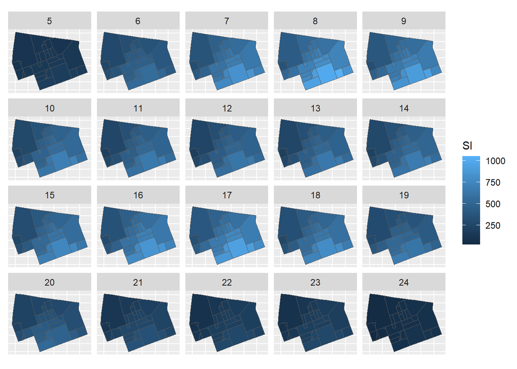

Victorian GTFS and SA1 zones within the Melbourne CBD - North SA2 zone, SI values for July 25, 2023, by hour between 5am and 1am

This appears to meet expectations, with peaks in the SI scores in morning and evening. SI scores also appear to be larger for zones closer to Melbourne Central station (south end of SA2 zone).

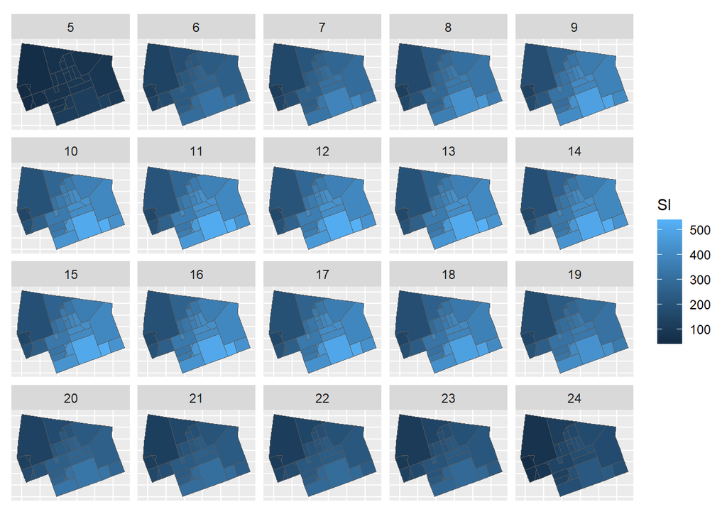

Victorian GTFS and SA1 zones within the Melbourne CBD - North SA2 zone, SI values for Saturday July 29th 2023, by hour between 5am and 1am

These results generally meet expectations. SI scores are in the order of half of the Tuesday scores, reflecting the lower service levels on Saturdays.

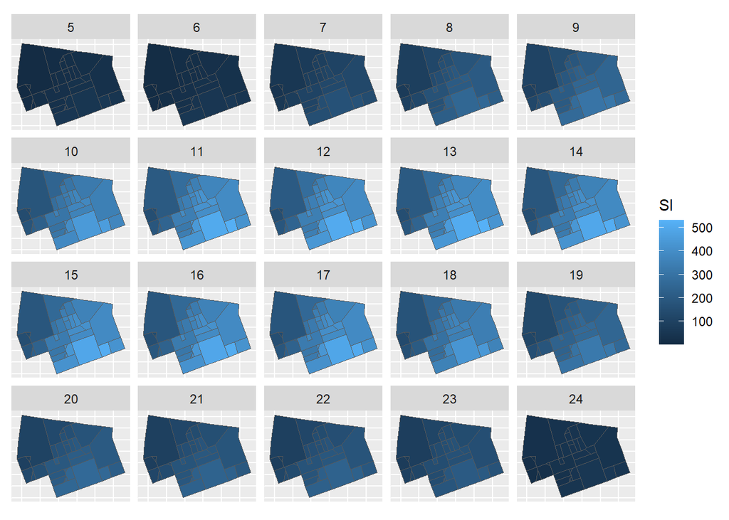

Victorian GTFS and SA1 zones within the Melbourne CBD - North SA2 zone, SI values for Sunday July 30th 2023, by hour between 5am and 1am

These results appear to meet expectations, with SI scores for the Sunday a relatively small amount lower than the Saturday scores

### Caulfield

The following shows calculated SI values for SA1 zones within the Caulfield - North SA2 zone, which includes the Caulfield campus of Monash Uni in the North East (close to Caulfield station), and zones close to Malvern Station (north of SA2 zone).

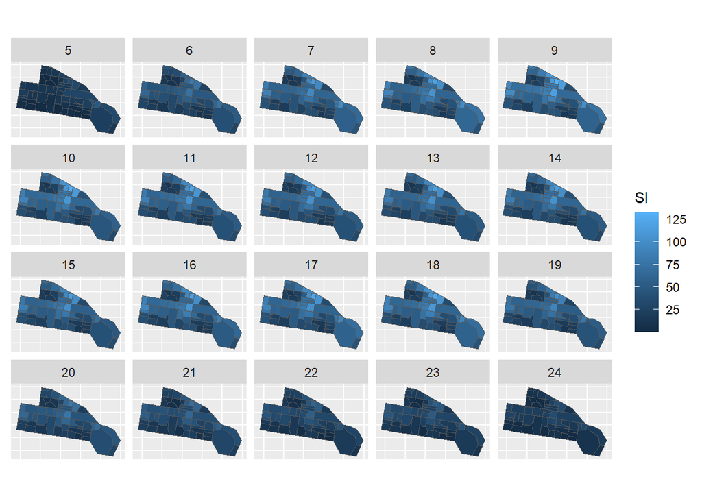

Victorian GTFS and SA1 zones within the Caulfield - NOrth SA2 zone, SI values for July 25th, 2023, by hour between 5am and 1am

Scores meet expectations, with higher scores closer to the railway stations and along tram routes along Balaclava Road (centre of SA2 zone)

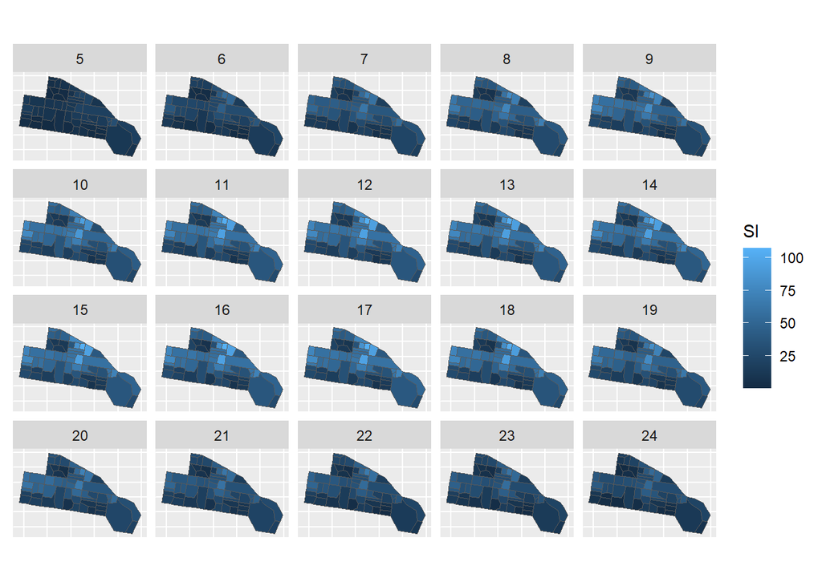

Victorian GTFS and SA1 zones within the Caulfield - North SA2 zone, SI values for July 29, 2023, by hour between 5am and 1am

Again, the Saturday scores are lower than for the weekday, although not to the same extent as in the CBD. This meets expectations.

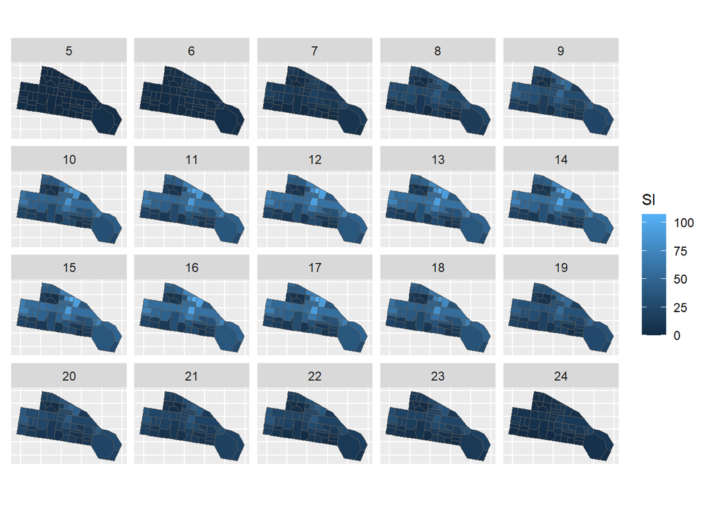

Victorian GTFS and SA1 zones within the Caulfield SA2 zone, SI values for July 30, 2023, by hour between 5am and 1am

Again, the Sunday sccores are similar to the Saturday scores, but lower in the early morngin and late evening. This meets expectations.

### Clayton

The following shows calculated SI values for SA1 zones within the Clayton (North) - Notting Hill SA2 zone.

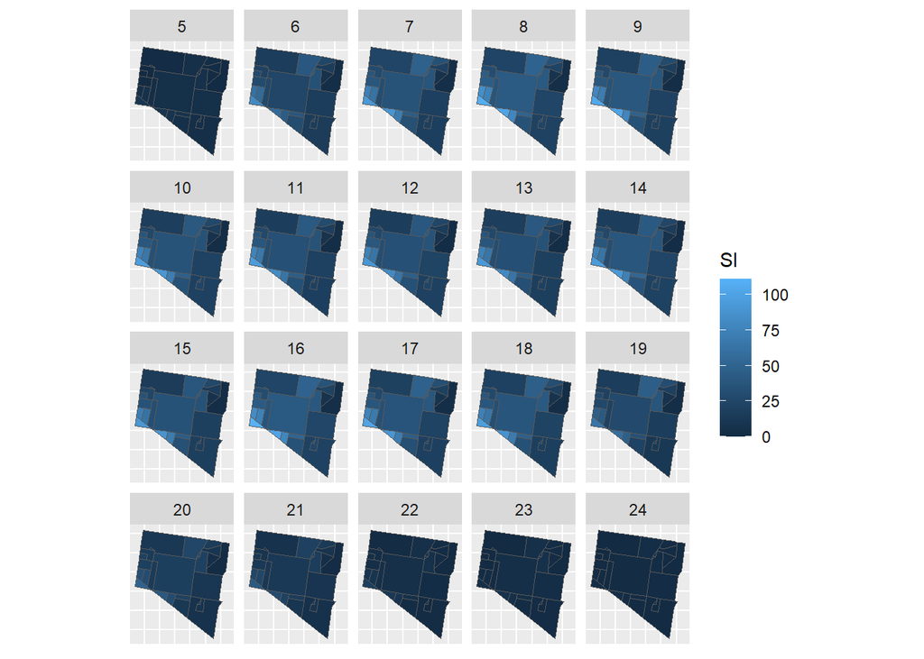

Victorian GTFS and SA1 zones within the Clayton (North) - NOtting Hill SA2 zone, SI values for July 25, 2023, by hour between 5am and 1am

These results appear to largely match expectations. SI values are much lower than in the Melbourne CBD. The highest SI scores are generally in the SA1 zones that are closest to the bus interchange at Monash University (south-west area of the SA2 area).

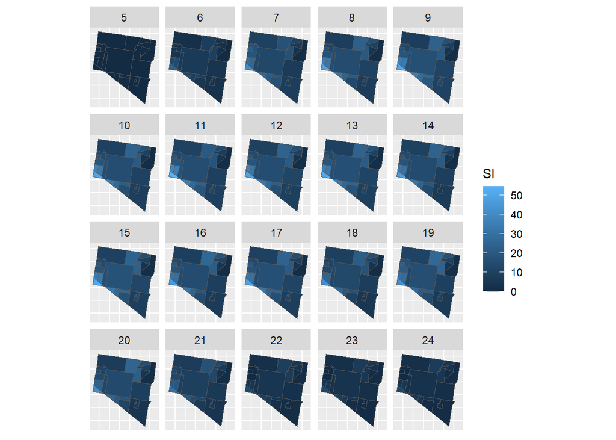

Victorian GTFS and SA1 zones within the Clayton (North) - NOtting Hill SA2 zone, SI values for July 29, 2023, by hour between 5am and 1am

Saturday scores are roughly half those of teh weekday. This meets expectations, given that there is little service to/from the university campus on weekends.

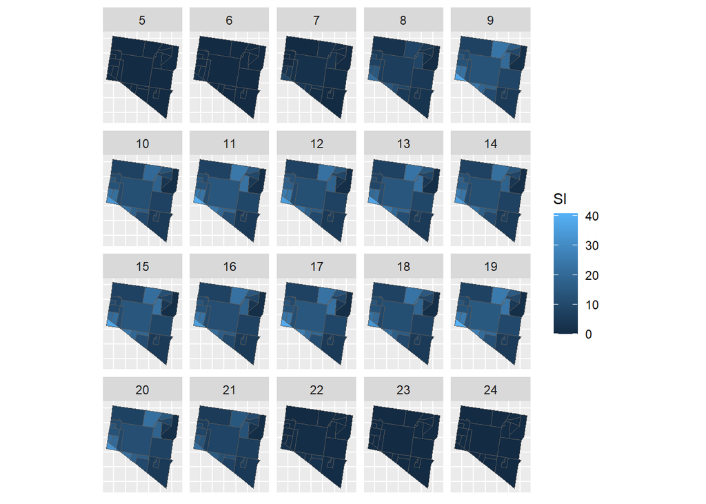

Victorian GTFS and SA1 zones within the Clayton (North) - NOtting Hill SA2 zone, SI values for July 30, 2023, by hour between 5am and 1am

Again, Sunday scores are slightly lower than Saturday scores, which meets expectations.

## Tram

Looking at the scores for trams only:

### Melbourne CBD - North

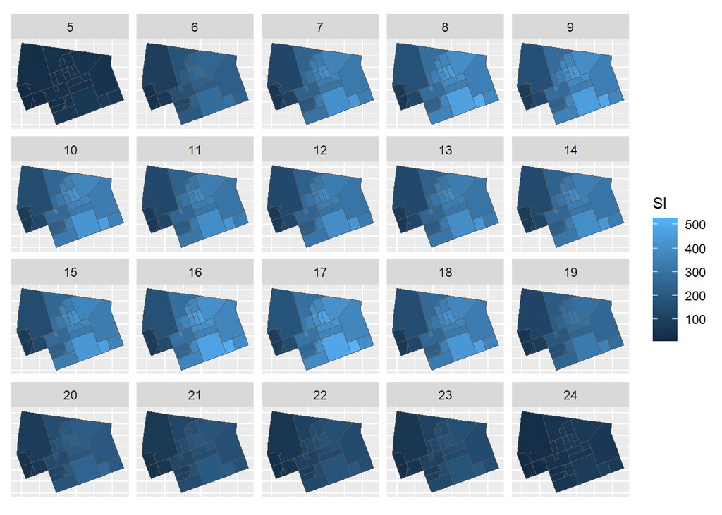

Victorian GTFS and SA1 zones within the Melbourne CBD - North SA2 zone, SI values for July 25, 2023, tram only, by hour between 5am and 1am

| area_id | 9:00 | 10:00 | 11:00 | 12:00 | 13:00 | 14:00 | 15:00 | 16:00 | 17:00 | 18:00 | 19:00 | 20:00 | 21:00 | 22:00 | 23:00 | 24:00 | 25:00 |
| --- | --- | --- | --- | --- | --- | --- | --- | --- | --- | --- | --- | --- | --- | --- | --- | --- | --- |
| 20604150424 | 347.55 | 334.63 | 307.59 | 304.8 | 307.34 | 311.83 | 333.62 | 368.9 | 371.78 | 335.5 | 255.37 | 196.24 | 160.72 | 144.61 | 145.27 | 65.22 | 2.54 |

This appears to meet expectations, with peaks in the SI scores in morning and evening. SI scores also appear to be larger for zones closer to the Swanston Street corridor

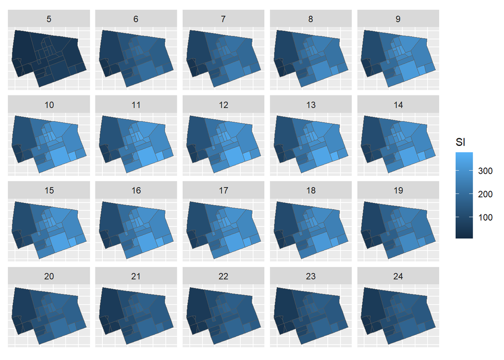

Victorian GTFS and SA1 zones within the Melbourne CBD - North SA2 zone, SI values for July 29th 2023, tram only, by hour between 5am and 1am

| area_id | 9:00 | 10:00 | 11:00 | 12:00 | 13:00 | 14:00 | 15:00 | 16:00 | 17:00 | 18:00 | 19:00 | 20:00 | 21:00 | 22:00 | 23:00 | 24:00 | 25:00 |
| --- | --- | --- | --- | --- | --- | --- | --- | --- | --- | --- | --- | --- | --- | --- | --- | --- | --- |
| 20604150424 | 256.87 | 274.65 | 278.45 | 277.54 | 275.74 | 272.1 | 273.23 | 272.04 | 272.57 | 252.03 | 222.09 | 167.6 | 150.67 | 145.15 | 142.62 | 143.11 | 80.97 |

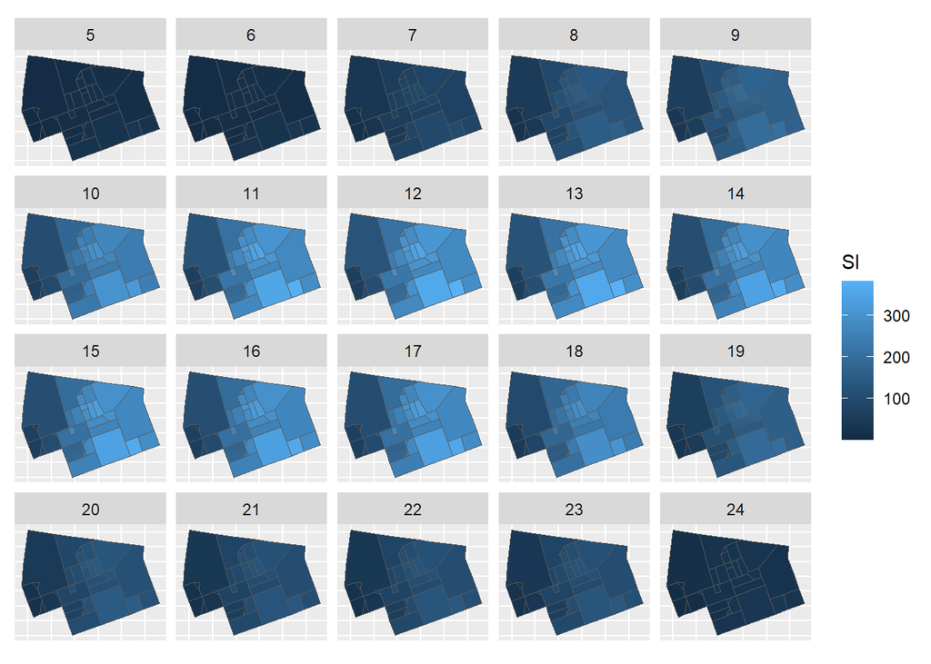

| area_id | 9:00 | 10:00 | 11:00 | 12:00 | 13:00 | 14:00 | 15:00 | 16:00 | 17:00 | 18:00 | 19:00 | 20:00 | 21:00 | 22:00 | 23:00 | 24:00 | 25:00 |
| --- | --- | --- | --- | --- | --- | --- | --- | --- | --- | --- | --- | --- | --- | --- | --- | --- | --- |
| 20604150424 | 161.27 | 240.57 | 275.31 | 277.33 | 278.68 | 271.31 | 273.23 | 271.61 | 272.57 | 237.87 | 158.09 | 118.63 | 106.99 | 107.3 | 106.89 | 25.13 | 0 |

These results appear to meet expectations, with SI scores for the Sunday lower than Saturday in the morning and evening.

### Caulfield

The following shows calculated SI values for SA1 zones within the Caulfield SA2 zone for each of the days of interest.

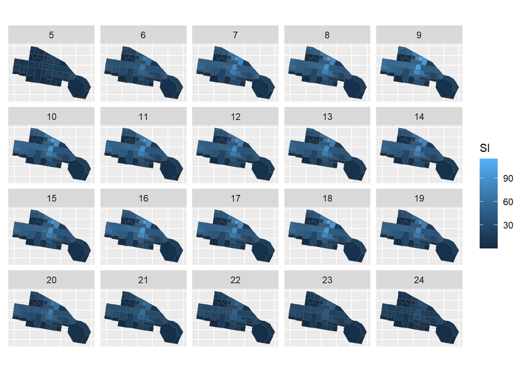

Victorian GTFS and SA1 zones within the Caulfield - North SA2 zone, SI values for July 25, 2023, by hour between 5am and 1am, tram only

This appears to meet expectations, with scores highest close to the Kooyong Rd (centre, N-s) and Balaclava Rd (centre, E-W) tram corridors.

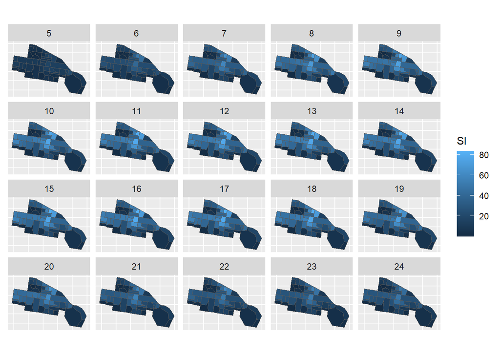

Victorian GTFS and SA1 zones within the Caulfield SA2 zone, SI values for July 29, 2023, by hour between 5am and 1am, tram only

This appears to meet expectations. Scores are a little lower than for the weekday, but have a similar geographic pattern.

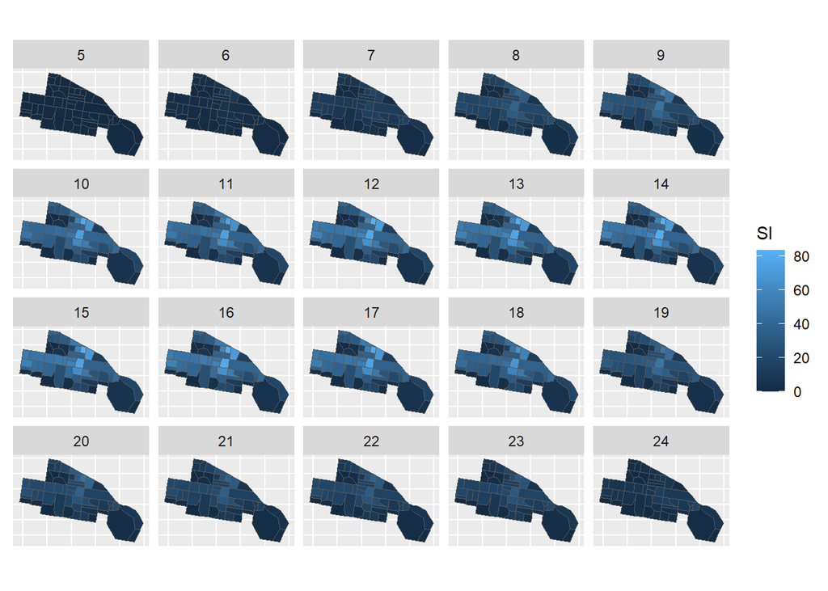

Victorian GTFS and SA1 zones within the Caulfield - NOrth SA2 zone, SI values for July 30, 2023, by hour between 5am and 1am, tram only

Likewise, the Sunday scores meet expectations. They are similar to the Saturday scores, but lower in the early morning and late evening.

## Rail

### Melbourne CBD - North

Looking next Melbourne CBD:

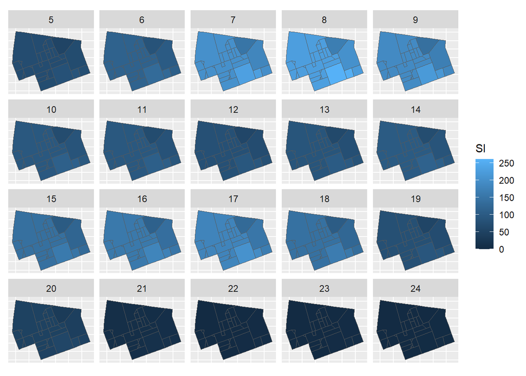

Victorian GTFS and SA1 zones within the Melbourne CBD - North SA2 zone, SI values for July 25th, 2023, rail only, by hour between 5am and 1am

| area_id | 5:00 | 6:00 | 7:00 | 8:00 | 9:00 | 10:00 | 11:00 | 12:00 | 13:00 | 14:00 | 15:00 | 16:00 | 17:00 | 18:00 | 19:00 | 20:00 | 21:00 | 22:00 | 23:00 | 24:00 | 25:00 | 26:00 |
| --- | --- | --- | --- | --- | --- | --- | --- | --- | --- | --- | --- | --- | --- | --- | --- | --- | --- | --- | --- | --- | --- | --- |
| 20604150424 | 69.69 | 100.62 | 182.74 | 203.88 | 170.06 | 86.07 | 82.97 | 71.37 | 76.97 | 86.31 | 120.61 | 138.44 | 153.77 | 124.08 | 70.75 | 43.25 | 9.61 | 2.93 | 2.93 | 1.46 | 0 | 0 |

This appears to meet expectations, with peaks in the SI scores in morning and evening. SI scores also appear to be larger for zones closer to Melbourne Central and Flagstaff.

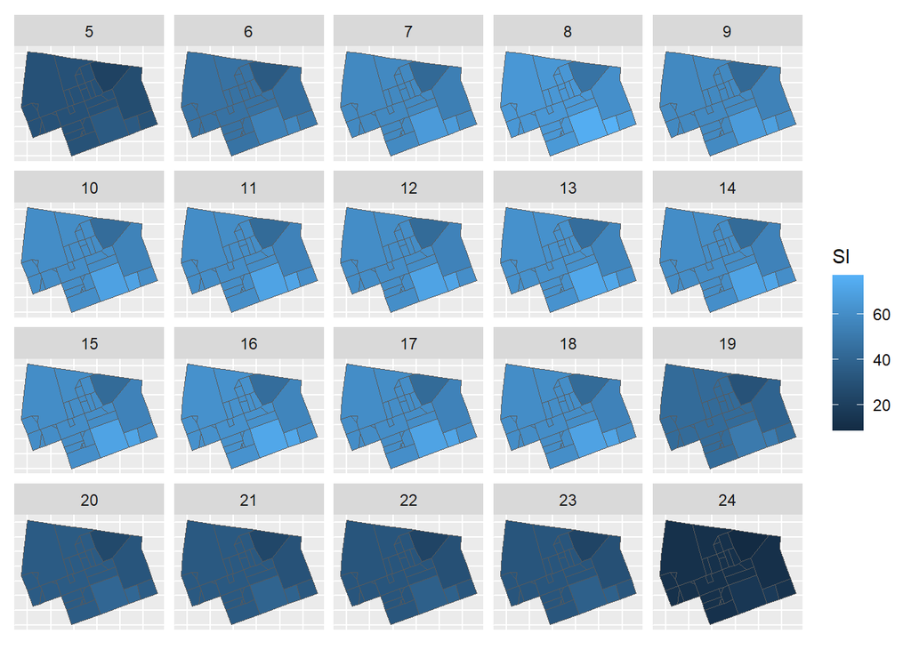

Victorian GTFS and SA1 zones within the Melbourne CBD - North SA2 zone, SI values for Saturday July 29th 2023, rail only, by hour between 5am and 1am

| area_id | 5:00 | 6:00 | 7:00 | 8:00 | 9:00 | 10:00 | 11:00 | 12:00 | 13:00 | 14:00 | 15:00 | 16:00 | 17:00 | 18:00 | 19:00 | 20:00 | 21:00 | 22:00 | 23:00 | 24:00 | 25:00 | 26:00 |
| --- | --- | --- | --- | --- | --- | --- | --- | --- | --- | --- | --- | --- | --- | --- | --- | --- | --- | --- | --- | --- | --- | --- |
| 20604150424 | 27.43 | 45.42 | 53.2 | 61.15 | 54.66 | 55.03 | 54.86 | 54.86 | 55.95 | 54.86 | 54.86 | 55.95 | 54.86 | 54.86 | 39.23 | 32.09 | 30.35 | 29.26 | 29.26 | 11.7 | 0 | 0 |

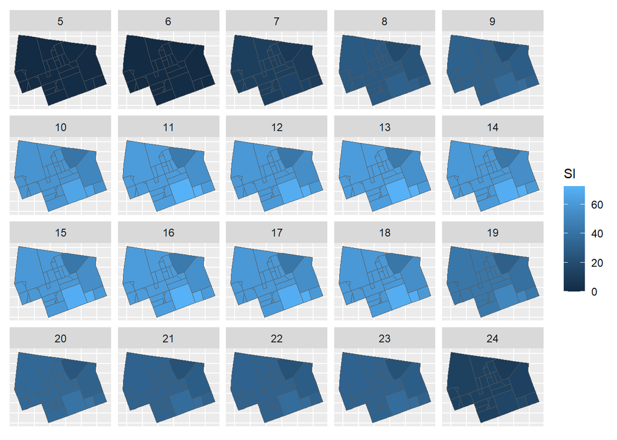

Victorian GTFS and SA1 zones within the Melbourne CBD - North SA2 zone, SI values for Sunday July 30th 2023, rail only, by hour between 5am and 1am

Victorian GTFS and Melbourne CBD SA1 zone 20604150424 (RMIT and State Library), hourly SI values for July 30th, 2023, 6am to 11pm only

| area_id | 6:00 | 7:00 | 8:00 | 9:00 | 10:00 | 11:00 | 12:00 | 13:00 | 14:00 | 15:00 | 16:00 | 17:00 | 18:00 | 19:00 | 20:00 | 21:00 | 22:00 |
| --- | --- | --- | --- | --- | --- | --- | --- | --- | --- | --- | --- | --- | --- | --- | --- | --- | --- |
| 20604150424 | 0 | 10.24 | 23.87 | 29.16 | 51.57 | 55.95 | 54.86 | 55.95 | 54.86 | 54.86 | 55.95 | 54.86 | 54.86 | 39.23 | 32.09 | 29.26 | 29.26 |

These results appear to meet expectations, with SI scores for the Sunday similar to the Saturday scores, only with less service in the morning and late evenings.

### Caulfield

The following shows calculated SI values for SA1 zones within the Caulfield SA2 zone for each of the days of interest.

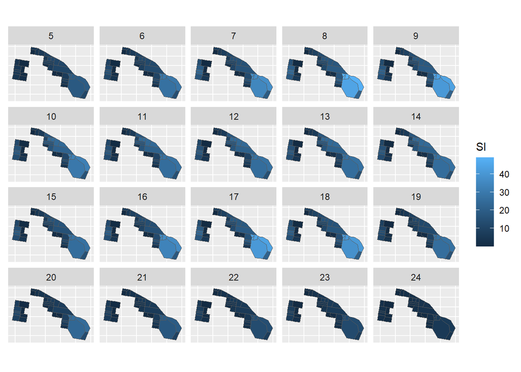

Victorian GTFS and SA1 zones within the Caulfield - NOrh SA2 zone, SI values for July 25, 2023, by hour between 5am and 1am, rail only

These scores appear to meet expectations, with scores only reported for SA1 zones close to railway lines (Sandringham line in the west, Malver and Caulfield stations in the north).

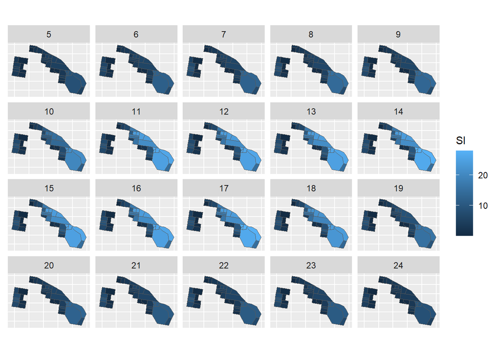

Victorian GTFS and SA1 zones within the Caulfield - NOrth SA2 zone, SI values for July 29, 2023, by hour between 5am and 1am, rail only

Saturday scores are roughly 3/5ths those of the weekday, again meeting expectations.

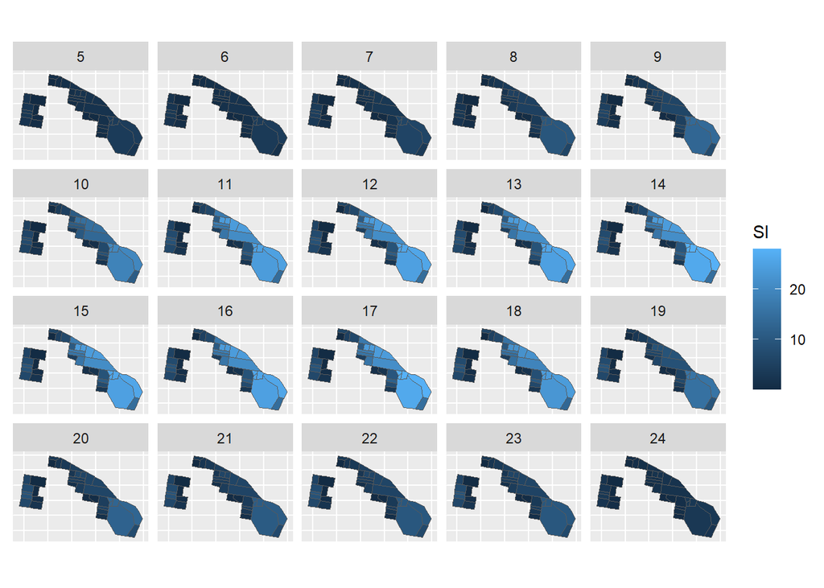

Victorian GTFS and SA1 zones within the Caulfield - North SA2 zone, SI values for July 30, 2023, by hour between 5am and 1am, rail only

Sunday scores are again simlar to Saturday, although lower in the early morning and late evening, again meeting expectations.

## Bus

### Lang Lang

Extracting SI score results for SA1 21201154812 for just the buss results in:

Victorian GTFS and Lang Lang SA1 zone 21201154812, hourly SI values for July 25, 2023, 6am to 11pm only

| area_id | 6:00 | 7:00 | 8:00 | 9:00 | 10:00 | 11:00 | 12:00 | 13:00 | 14:00 | 15:00 | 16:00 | 17:00 | 18:00 | 19:00 | 20:00 | 21:00 | 22:00 |
| --- | --- | --- | --- | --- | --- | --- | --- | --- | --- | --- | --- | --- | --- | --- | --- | --- | --- |
| 21201154812 | 1.78 | 3.56 | 1.78 | 0 | 1.78 | 1.78 | 1.78 | 1.78 | 1.78 | 1.78 | 1.78 | 1.78 | 1.78 | 1.78 | 1.78 | 0 | 1.78 |

This matches the pattern shown above in the total (all modes) results) with a small amount of service throughout the day.

### Melbourne CBD - North

Looking next Melbourne CBD:

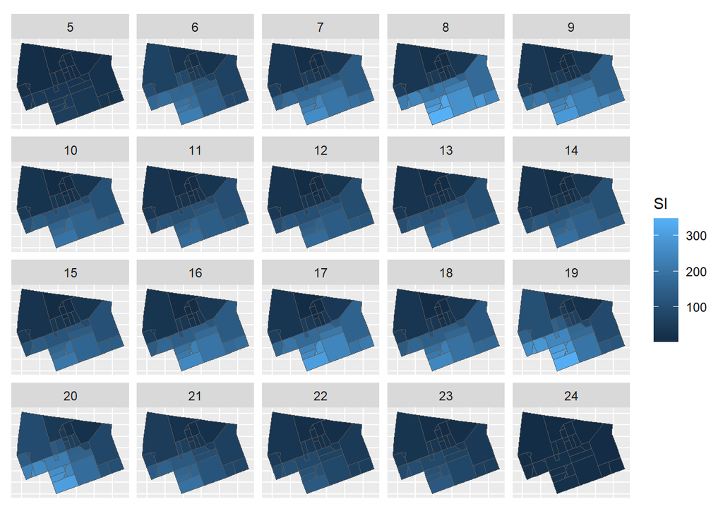

Victorian GTFS and SA1 zones within the Melbourne CBD - North SA2 zone, SI values for July 25, 2023, bus only, by hour between 5am and 1am

Victorian GTFS and Melbourne CBD SA1 zone 20604150424 (RMIT and State Library), hourly SI values for July 25, 2023, 6am to 11pm only

| area_id | 6:00 | 7:00 | 8:00 | 9:00 | 10:00 | 11:00 | 12:00 | 13:00 | 14:00 | 15:00 | 16:00 | 17:00 | 18:00 | 19:00 | 20:00 | 21:00 | 22:00 |
| --- | --- | --- | --- | --- | --- | --- | --- | --- | --- | --- | --- | --- | --- | --- | --- | --- | --- |
| 20604150424 | 69.2 | 133.18 | 175.48 | 146.59 | 108.71 | 99.99 | 97.29 | 101.74 | 105.34 | 107.36 | 135.24 | 154.27 | 126.14 | 90.65 | 78.28 | 63.21 | 44.62 |

This appears to meet expectations, with peaks in the SI scores in morning and evening. SI scores also appear to be larger for zones closer to the Queen and Lonsdale Street corridors

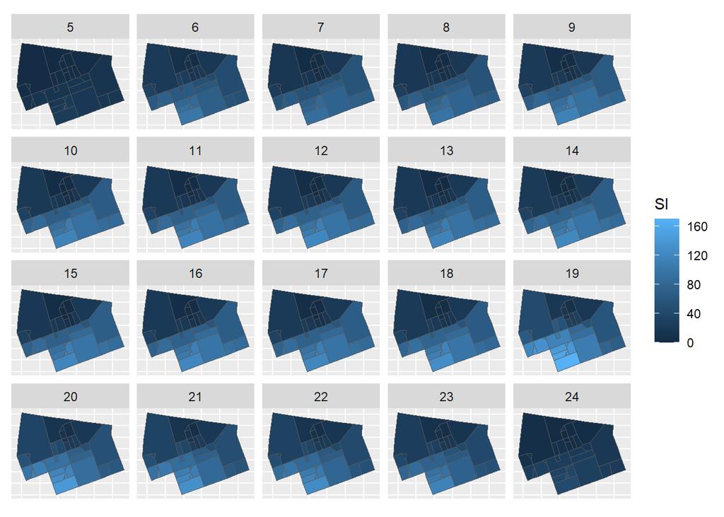

Victorian GTFS and Melbourne CBD SA1 zone 20604150424 (RMIT and State Library), hourly SI values for July 29th, 2023, 6am to 11pm only

| area_id | 6:00 | 7:00 | 8:00 | 9:00 | 10:00 | 11:00 | 12:00 | 13:00 | 14:00 | 15:00 | 16:00 | 17:00 | 18:00 | 19:00 | 20:00 | 21:00 | 22:00 |
| --- | --- | --- | --- | --- | --- | --- | --- | --- | --- | --- | --- | --- | --- | --- | --- | --- | --- |
| 20604150424 | 46.53 | 56.62 | 55.32 | 63.93 | 67.56 | 65.35 | 65.51 | 67.8 | 69.54 | 69.81 | 68.81 | 67.91 | 65.94 | 57.54 | 51.83 | 48.37 | 43.16 |

These results generally meet expectations. SI scores are in the order of 1/2 of the Tuesday scores, reflecting the lower service levels on Saturdays.

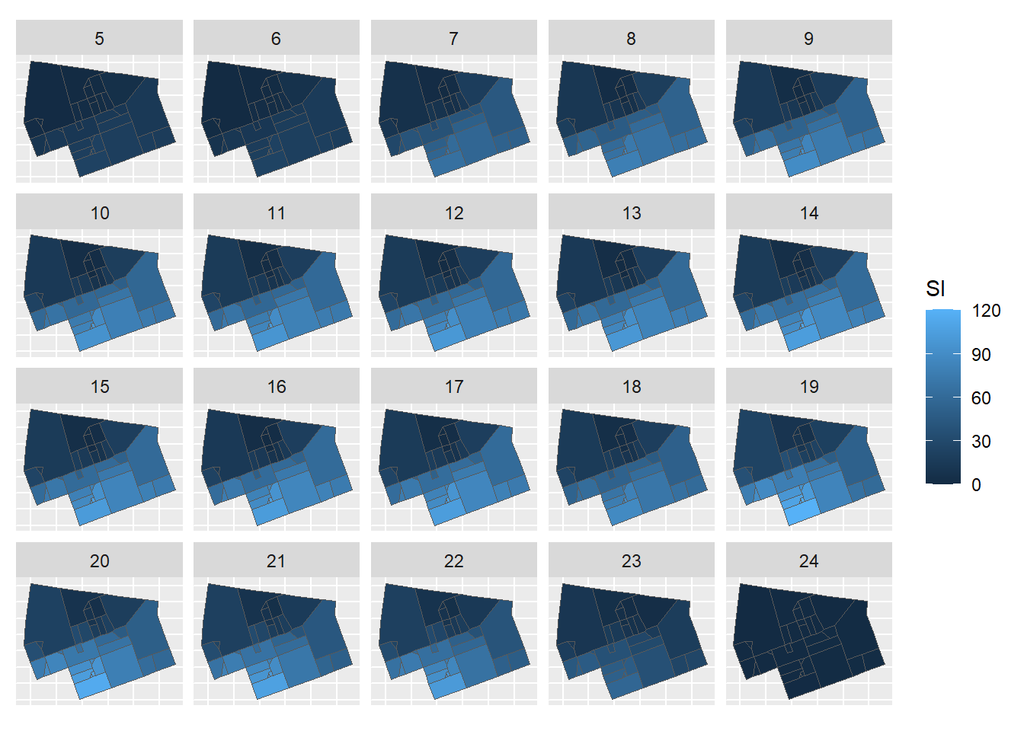

Victorian GTFS and SA1 zones within the Melbourne CBD - North SA2 zone, SI values for Sunday 30th July, 2023, bus only, by hour between 5am and 1am

Victorian GTFS and Melbourne CBD SA1 zone 20604150424 (RMIT and State Library), hourly SI values for July 30th, 2023, 6am to 11pm only

| area_id | 6:00 | 7:00 | 8:00 | 9:00 | 10:00 | 11:00 | 12:00 | 13:00 | 14:00 | 15:00 | 16:00 | 17:00 | 18:00 | 19:00 | 20:00 | 21:00 | 22:00 |
| --- | --- | --- | --- | --- | --- | --- | --- | --- | --- | --- | --- | --- | --- | --- | --- | --- | --- |
| 20604150424 | 16.31 | 43.87 | 52.58 | 54.05 | 57.18 | 59.66 | 58.14 | 59.9 | 60.93 | 60.37 | 61.27 | 60.8 | 51.56 | 51.92 | 49.78 | 43.08 | 39.91 |

### Caulfield

The following shows calculated SI values for SA1 zones within the Caulfield SA2 zone for each of the days of interest.

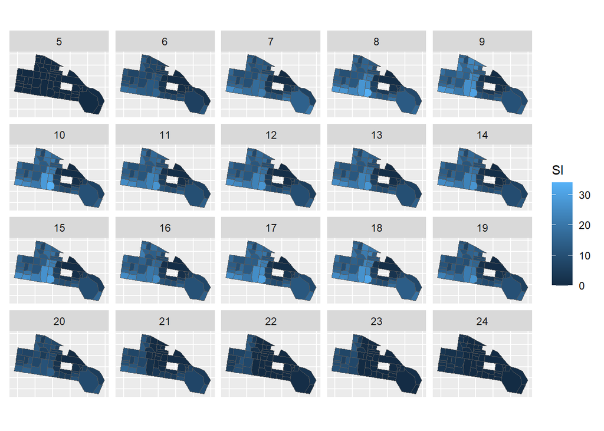

Victorian GTFS and SA1 zones within the Caulfield - NOrh SA2 zone, SI values for July 25, 2023, by hour between 5am and 1am, bus only

Results appear to generally match the greographic distribution of bus routes in the area.

See https://www.ptv.vic.gov.au/assets/PTV-default-site/more/maps/Local-area-maps/Metropolitan/16_Glen-Eira_LAM_September-2021.pdf

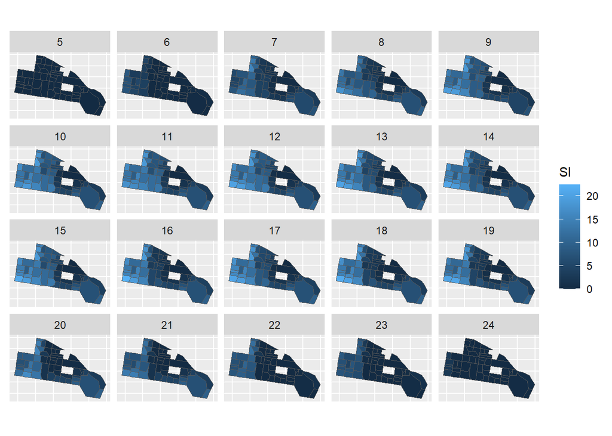

Victorian GTFS and SA1 zones within the Caulfield - NOrth SA2 zone, SI values for July 29, 2023, by hour between 5am and 1am, bus only

Saturday scores are genearlly lower than the weekday, which meets expectations.

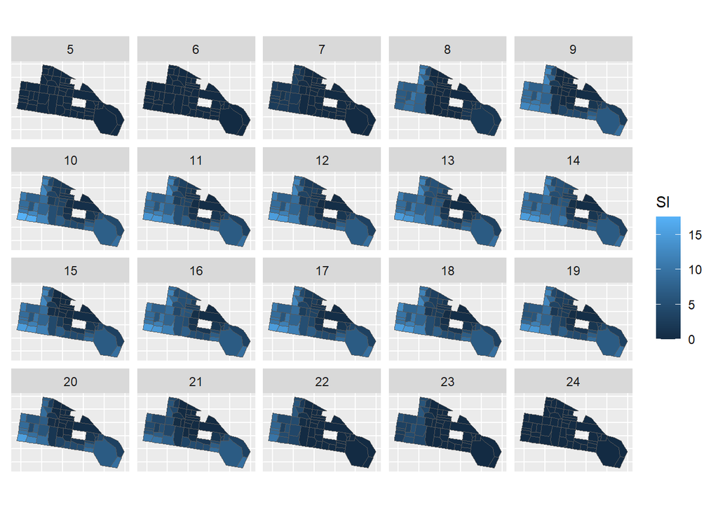

Victorian GTFS and SA1 zones within the Caulfield - North SA2 zone, SI values for July 30, 2023, by hour between 5am and 1am, bus only

Again, Suday scores are a bit lower than the Saruday scores, especially in the early morning. This meets expectations.

### Clayton

The following shows calculated SI values for SA1 zones within the Clayton (North) - Notting Hill SA2 zone for each of the days of interest.

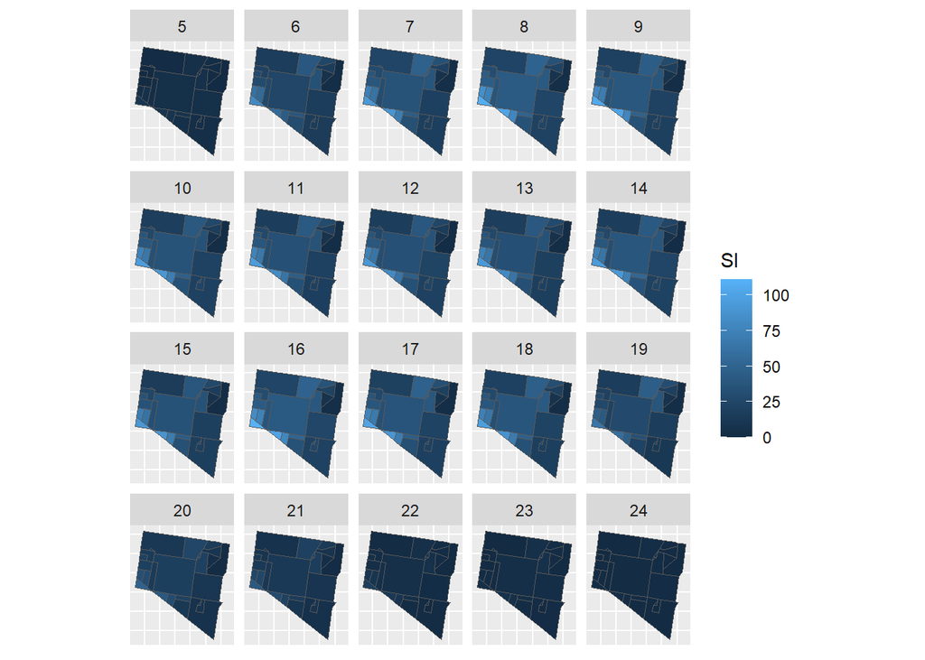

Victorian GTFS and SA1 zones within the Clayton (North) - NOtting Hill SA2 zone, SI values for July 25, 2023, by hour between 5am and 1am, bus only

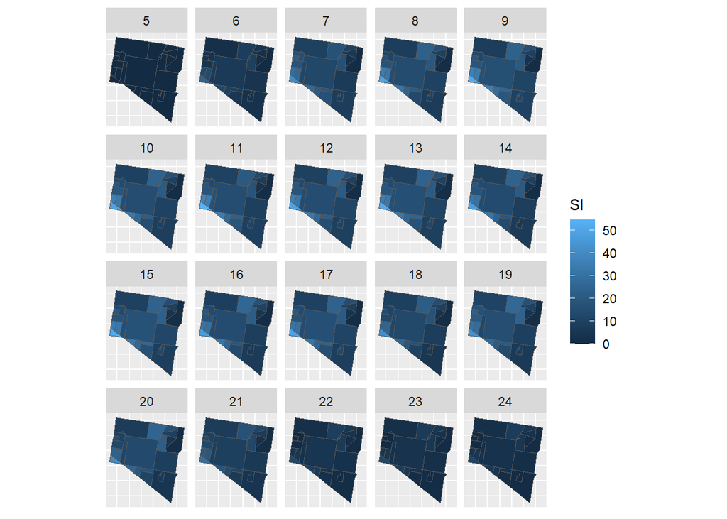

Victorian GTFS and SA1 zones within the Clayton (North) - NOtting Hill SA2 zone, SI values for July 29, 2023, by hour between 5am and 1am, bus only

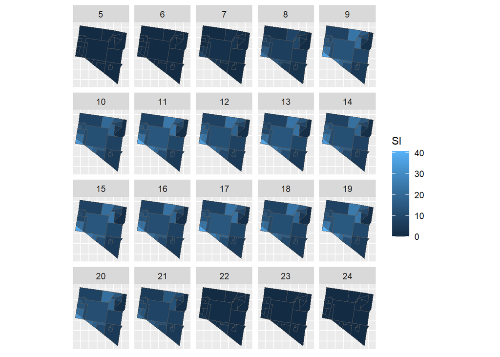

Victorian GTFS and SA1 zones within the Clayton (North) - NOtting Hill SA2 zone, SI values for July 30, 2023, by hour between 5am and 1am, bus only

Again, these scores all appear to meet expectations.

# Discussion and conclusions

Potentially relating to a strike.

These calculations have been done using the new gtfssupplyindex R package, and results generally appear to meet expectations. More detailed testing of the code and hand calculation to check results has been reported in the documentation for the package on github (Reynolds 2024), although there is further work to be done there.

Reynolds, James. 2024. “Gtfssupplyindex.” https://github.com/James-Reynolds/gtfssupplyindex.

Calculation speed is much improved from previous efforts (in mid-2023)! The three days of calculations ran overnight, and were completed in the morning.

Next steps might involve further development of the gtfssupplyindex package. Further exploration of the SA1 scores for Greater Melbourne that have been calculated here might also be undertaken, or further dates.